# DATA151: Tidyr and Joins

### PART II: Joins

There are three types of joins that we will look at:

- Inner Join: Looks for only elements that exist in both dataframes
- Left Join (or Right Join): Matches elements from the left dataframe to the right

#### Toy Example

##### Step 1: Load Data

Tibbles are like data frames that can be more easily manipulated in the tidyverse. In this example we create a tibble for comic book characters.

```r
# a tibble is a type of a data frame

superheroes <- tibble::tribble(
  ~name, ~alignment,  ~gender,          ~publisher,
  "Magneto",      "bad",   "male",            "Marvel",
  "Storm",     "good", "female",            "Marvel",
  "Mystique",      "bad", "female",            "Marvel",
  "Batman",     "good",   "male",                "DC",
  "Joker",      "bad",   "male",                "DC",
  "Catwoman",      "bad", "female",                "DC",
  "Hellboy",     "good",   "male", "Dark Horse Comics"
)

publishers <- tibble::tribble(
  ~publisher, ~yr_founded,
  "DC",       1934L,
  "Marvel",       1939L,
  "Image",       1992L
)
```

##### Step 2: Inner Join

```r
# inner join super hero and publisher
insp<-inner_join(superheroes, publishers)
insp
```

```
## # A tibble: 6 × 5
##   name     alignment gender publisher yr_founded
##   <chr>    <chr>     <chr>  <chr>          <int>
## 1 Magneto  bad       male   Marvel          1939
## 2 Storm    good      female Marvel          1939
## 3 Mystique bad       female Marvel          1939
## 4 Batman   good      male   DC              1934
## 5 Joker    bad       male   DC              1934
## 6 Catwoman bad       female DC              1934
```

##### Step 3: Left Join

```r
# left join super hero and publisher
ljsp<-left_join(superheroes, publishers)
ljsp
```

```
## # A tibble: 7 × 5
##   name     alignment gender publisher         yr_founded
##   <chr>    <chr>     <chr>  <chr>                  <int>
## 1 Magneto  bad       male   Marvel                  1939
## 2 Storm    good      female Marvel                  1939
## 3 Mystique bad       female Marvel                  1939
## 4 Batman   good      male   DC                      1934
## 5 Joker    bad       male   DC                      1934
## 6 Catwoman bad       female DC                      1934
## 7 Hellboy  good      male   Dark Horse Comics         NA
```

#### Real World Example: NBA

##### Step 1: Load Data

*Data Set #1: NBA Salaries*

All NBA Player’s salaries 2019-2020.

Scrape from ESPN (http://www.espn.com/nba/salaries).

Hosted on Kaggle at:

https://www.kaggle.com/datasets/junfenglim/nba-player-salaries-201920

```r
## SALARY DATA for 2019-2020 season
salaries1920 <- read.csv("https://raw.githubusercontent.com/kitadasmalley/DATA151/main/Data/nba2019-20.csv", header=TRUE)
```

*Data Set #2: NBA Players*

The data set contains over two decades of data on each player who has been part of an NBA teams’ roster. It captures demographic variables such as age, height, weight and place of birth, biographical details like the team played for, draft year and round. In addition, it has basic box score statistics such as games played, average number of points, rebounds, assists, etc.

These data are hosted on Kaggle at:

https://www.kaggle.com/datasets/justinas/nba-players-data

```r
## METRICS ON PLAYER PERFORMANCE
## 1996 to 2022
all_seasons <- read.csv("https://raw.githubusercontent.com/kitadasmalley/DATA151/main/Data/all_seasons.csv", header=TRUE)
```

##### Step 2: Learn about your data

```r
# SALARIES
## INSERT CODE HERE ##
str(salaries1920)
```

```
## 'data.frame':    528 obs. of  5 variables:
##  $ team    : chr  "Golden State Warriors" "Oklahoma City Thunder" "Houston Rockets" "Washington Wizards" ...
##  $ salary  : int  40231758 38506482 38506482 38199000 38199000 38199000 37436858 34996296 34449964 32742000 ...
##  $ player  : chr  "Stephen Curry" "Chris Paul" "Russell Westbrook" "John Wall" ...
##  $ position: chr  " PG" " PG" " PG" " PG" ...
##  $ season  : chr  "2019-2020" "2019-2020" "2019-2020" "2019-2020" ...
```

```r
# METRICS
## INSERT CODE HERE ##
str(all_seasons)
```

```
## 'data.frame':    12305 obs. of  22 variables:
##  $ X                : int  0 1 2 3 4 5 6 7 8 9 ...
##  $ player_name      : chr  "Dennis Rodman" "Dwayne Schintzius" "Earl Cureton" "Ed O'Bannon" ...
##  $ team_abbreviation: chr  "CHI" "LAC" "TOR" "DAL" ...
##  $ age              : num  36 28 39 24 34 38 25 28 29 28 ...
##  $ player_height    : num  198 216 206 203 206 ...
##  $ player_weight    : num  99.8 117.9 95.3 100.7 108.9 ...
##  $ college          : chr  "Southeastern Oklahoma State" "Florida" "Detroit Mercy" "UCLA" ...
##  $ country          : chr  "USA" "USA" "USA" "USA" ...
##  $ draft_year       : chr  "1986" "1990" "1979" "1995" ...
##  $ draft_round      : chr  "2" "1" "3" "1" ...
##  $ draft_number     : chr  "27" "24" "58" "9" ...
##  $ gp               : int  55 15 9 64 27 52 80 77 71 82 ...
##  $ pts              : num  5.7 2.3 0.8 3.7 2.4 8.2 17.2 14.9 5.7 6.9 ...
##  $ reb              : num  16.1 1.5 1 2.3 2.4 2.7 4.1 8 1.6 1.5 ...
##  $ ast              : num  3.1 0.3 0.4 0.6 0.2 1 3.4 1.6 1.3 3 ...
##  $ net_rating       : num  16.1 12.3 -2.1 -8.7 -11.2 4.1 4.1 3.3 -0.3 -1.2 ...
##  $ oreb_pct         : num  0.186 0.078 0.105 0.06 0.109 0.034 0.035 0.095 0.036 0.018 ...
##  $ dreb_pct         : num  0.323 0.151 0.102 0.149 0.179 0.126 0.091 0.183 0.076 0.081 ...
##  $ usg_pct          : num  0.1 0.175 0.103 0.167 0.127 0.22 0.209 0.222 0.172 0.177 ...
##  $ ts_pct           : num  0.479 0.43 0.376 0.399 0.611 0.541 0.559 0.52 0.539 0.557 ...
##  $ ast_pct          : num  0.113 0.048 0.148 0.077 0.04 0.102 0.149 0.087 0.141 0.262 ...
##  $ season           : chr  "1996-97" "1996-97" "1996-97" "1996-97" ...
```

##### Step 3: Wrangle your data

We need to make an apples to apples comparison.

- Filter the season data by 2019-2020 season.
- We also need to have the same name for the variable we wish to match.

```r
## INSERT CODE HERE ##
season1920<-all_seasons%>%
  filter(season=="2019-20")%>%
  select(-season)%>%
  rename(player=player_name)

str(season1920)
```

```
## 'data.frame':    529 obs. of  21 variables:
##  $ X                : int  10631 10632 10633 10634 10635 10636 10637 10638 10639 10640 ...
##  $ player           : chr  "Aaron Holiday" "Maxi Kleber" "Max Strus" "Maurice Harkless" ...
##  $ team_abbreviation: chr  "IND" "DAL" "CHI" "NYK" ...
##  $ age              : num  23 28 24 27 29 25 23 23 30 34 ...
##  $ player_height    : num  183 208 196 201 190 ...
##  $ player_weight    : num  83.9 108.9 97.5 99.8 90.7 ...
##  $ college          : chr  "UCLA" "None" "DePaul" "St. John's" ...
##  $ country          : chr  "USA" "Germany" "USA" "USA" ...
##  $ draft_year       : chr  "2018" "Undrafted" "Undrafted" "2012" ...
##  $ draft_round      : chr  "1" "Undrafted" "Undrafted" "1" ...
##  $ draft_number     : chr  "23" "Undrafted" "Undrafted" "15" ...
##  $ gp               : int  66 74 2 62 57 41 4 65 61 58 ...
##  $ pts              : num  9.5 9.1 2.5 5.8 3.1 4.9 0.5 4.7 7.2 5.9 ...
##  $ reb              : num  2.4 5.2 0.5 3.9 1.3 1.5 0.8 1.6 5.2 3.2 ...
##  $ ast              : num  3.4 1.2 0 1.1 3.2 0.5 0.3 1.2 2.5 1 ...
##  $ net_rating       : num  2.2 3.4 105.8 1.2 -1.2 ...
##  $ oreb_pct         : num  0.013 0.054 0.167 0.038 0.022 0.018 0 0.033 0.087 0.025 ...
##  $ dreb_pct         : num  0.077 0.136 0 0.117 0.067 0.1 0.158 0.049 0.195 0.132 ...
##  $ usg_pct          : num  0.182 0.134 0.158 0.105 0.128 0.152 0.08 0.108 0.173 0.12 ...
##  $ ts_pct           : num  0.521 0.605 0.727 0.572 0.463 0.65 0.25 0.539 0.613 0.587 ...
##  $ ast_pct          : num  0.188 0.065 0 0.062 0.297 0.076 0.071 0.081 0.21 0.076 ...
```

##### Step 4: Join the data

```r
## WHAT KIND OF JOIN SHOULD WE USE?
## INSERT CODE HERE ##
joinNBA<-salaries1920%>%
  left_join(season1920)
```

##### Step 5: Visualize

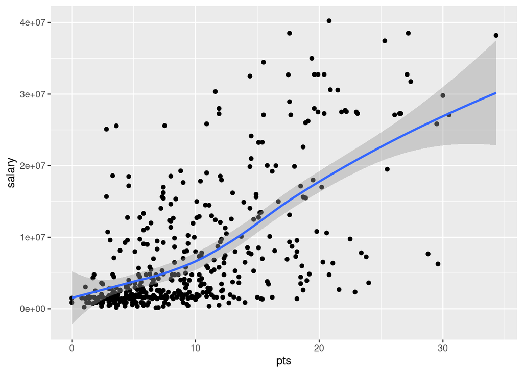

```r
## GGPLOT2
## INSERT CODE HERE ##

ggplot(joinNBA, aes(x=pts, y=salary))+
  geom_point()+
  geom_smooth()
```

### PART III: BONUS Tidy Material

#### Combine columns with `unite`

##### Step 1: Create Data

```r
# lets create more fake data for dates and times
set.seed(1)
date <- as.Date('2016-01-01') + 0:14
hour <- sample(1:24, 15)
min <- sample(1:60, 15)
second <- sample(1:60, 15)
event <- sample(letters, 15)
data <- data.frame(date, hour, min, second, event)
data
```

```
##          date hour min second event
## 1  2016-01-01    4  15     35     w
## 2  2016-01-02    7  21      6     x
## 3  2016-01-03    1  37     10     f
## 4  2016-01-04    2  41     42     g
## 5  2016-01-05   11  25     38     s
## 6  2016-01-06   14  46     47     j
## 7  2016-01-07   18  58     20     y
## 8  2016-01-08   22  54     28     n
## 9  2016-01-09    5  34     54     b
## 10 2016-01-10   16  42     44     m
## 11 2016-01-11   10  56     23     r
## 12 2016-01-12    6  44     59     t
## 13 2016-01-13   19  60     40     v
## 14 2016-01-14   23  33     51     o
## 15 2016-01-15    9  20     25     a
```

##### Step 2: Unite

```r
dataUnite <- data %>%
  unite(datehour, date, hour, sep = ' ') %>%
  unite(datetime, datehour, min, second, sep = ':')

str(dataUnite)
```

```
## 'data.frame':    15 obs. of  2 variables:
##  $ datetime: chr  "2016-01-01 4:15:35" "2016-01-02 7:21:6" "2016-01-03 1:37:10" "2016-01-04 2:41:42" ...
##  $ event   : chr  "w" "x" "f" "g" ...
```

##### Step 3: Separate

```r
# seperate
dataSep <- dataUnite %>%
  separate(datetime, c('date', 'time'), sep = ' ') %>%
  separate(time, c('hour', 'min', 'second'), sep = ':')

dataSep
```

```
##          date hour min second event
## 1  2016-01-01    4  15     35     w
## 2  2016-01-02    7  21      6     x
## 3  2016-01-03    1  37     10     f
## 4  2016-01-04    2  41     42     g
## 5  2016-01-05   11  25     38     s
## 6  2016-01-06   14  46     47     j
## 7  2016-01-07   18  58     20     y
## 8  2016-01-08   22  54     28     n
## 9  2016-01-09    5  34     54     b
## 10 2016-01-10   16  42     44     m
## 11 2016-01-11   10  56     23     r
## 12 2016-01-12    6  44     59     t
## 13 2016-01-13   19  60     40     v
## 14 2016-01-14   23  33     51     o
## 15 2016-01-15    9  20     25     a
```